# ACP normée des lignes d’entraînement

Projet décrochage MCO · 11 587 passages d’entraînement, 38 variables actives · table c70074d0db8951603526bc9c92d4b50d · rendu le 21/11/2026

## 0. Ce qui a été fait avant l’ACP

- **Individus** : les 11 587 passages évalués de l’entraînement. Ils viennent de 1634 établissements, présents 8 années en médiane : **un même établissement est un individu par année**, et les très grands sites pèsent plusieurs fois (partie 3).
- **Variables actives** (38) : les 29 quantités MCO, l’activité et le nombre de sites de l’entité, passés par log(1 + x) ; les 6 ratios et la part du site dans son entité. Le taux d’occupation et la durée moyenne de séjour sont plafonnés à leur 99<sup>e</sup> centile (1,114 et 23,3 jours), pour l’ACP seulement.
- **Cases vides** remplacées par la médiane, pour l’ACP seulement : lit_med (40), lit_chi (11), lit_obs (44), lit_mco (1), jli_med (95), jli_chi (23), jli_obs (80), jli_mco (2), jou_med (1), jou_chi (6), jou_obs (9), sejhc_med (1), sejhc_chi (6), sejhc_obs (9), sej0_med (3), sej0_chi (9), sej0_obs (9), sej0_mco (2), pla_med (187), pla_chi (10), pla_obs (269), pla_mco (21), sejhp_med (8), sejhp_chi (10), sejhp_obs (12), sejhp_mco (8), sea_mco (9), taux_occupation_mco (135), part_partielle_mco (8), duree_moyenne_sejour_mco (139), part_journees_med (137), part_journees_chi (142), part_journees_obs (145).
- **ACP normée** (`FactoMineR::PCA`, `scale.unit = TRUE`) : chaque variable est centrée et réduite (moyenne au plus 2.9e-16 en valeur absolue après réduction), on diagonalise la matrice des corrélations, la somme des valeurs propres vaut 38,00 (le nombre de variables) et la valeur propre moyenne vaut 1.
- **Éléments supplémentaires** (ils ne construisent pas les axes) : la classe (stable, décrochage, sortie), le statut, la catégorie, la région, les indicateurs d’offre et d’incohérence.

## 1. Combien d’axes retenir ?

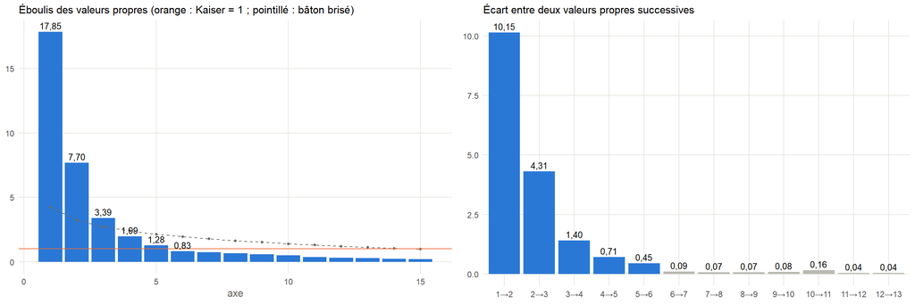

| axe | valeur propre | % d’inertie | % cumulé | écart avec la suivante | bâton brisé |
| --- | --- | --- | --- | --- | --- |
| 1,00 | 17,85 | 46,97 | 46,97 | 10,15 | 4,23 |
| 2,00 | 7,70 | 20,26 | 67,23 | 4,31 | 3,23 |
| 3,00 | 3,39 | 8,92 | 76,15 | 1,40 | 2,73 |
| 4,00 | 1,99 | 5,22 | 81,37 | 0,71 | 2,39 |
| 5,00 | 1,28 | 3,36 | 84,73 | 0,45 | 2,14 |
| 6,00 | 0,83 | 2,18 | 86,90 | 0,09 | 1,94 |
| 7,00 | 0,74 | 1,93 | 88,84 | 0,07 | 1,78 |
| 8,00 | 0,66 | 1,74 | 90,58 | 0,07 | 1,64 |
| 9,00 | 0,59 | 1,56 | 92,15 | 0,08 | 1,51 |
| 10,00 | 0,51 | 1,35 | 93,50 | 0,16 | 1,40 |

**Kaiser** : 5 valeurs propres sont supérieures à 1 (la 5<sup>e</sup> vaut 1,28, la 6<sup>e</sup> 0,83). Au-delà, chaque axe porte moins qu’une seule variable : c’est du bruit.

**Les écarts** : 10,15 ; 4,31 ; 1,40 ; 0,71 ; 0,45, puis 0,09 ; 0,07 ; 0,07 ; 0,08. Le premier grand décrochage est entre les axes 1 et 2 (l’effet taille, partie 2). Il y a aussi une rupture à 3, mais les écarts suivants restent nettement au-dessus du niveau du bruit : couper à 3 laisserait deux axes qui ne sont pas du bruit. La pente ne s’aplatit qu’après l’axe 5 : l’écart 5→6 (0,45) vaut environ 6 fois les suivants.

**Le bâton brisé**, repère plus sévère, ne garde que 3 axes : la 4<sup>e</sup> valeur propre (1,99) est sous son seuil (2,39).

**Décision (21/11/2026) : 5 axes retenus** (84,7 % de l’inertie). Kaiser et l’aplatissement des écarts s’accordent ; les axes 4 et 5, plus fragiles selon le bâton brisé, sont lus avec prudence.

## 2. L’espace des variables (espace dual)

Chaque variable réduite est un vecteur de norme 1. Sa coordonnée sur un axe est sa **corrélation** avec l’axe ; le carré de cette coordonnée (cos²) est la part de la variable représentée par l’axe ; sur un plan, le cos² est la somme des deux, le carré de la longueur de la flèche. La **contribution** d’une variable à un axe est sa coordonnée au carré divisée par la valeur propre (moyenne : 100 / 38 = 2,6 %).

### 2.1 Qualité de représentation

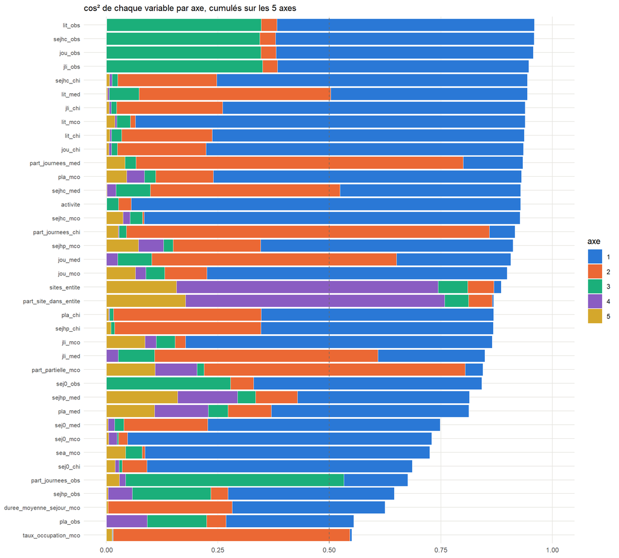

**Sur le plan 1-2**, 6 variables ont un cos² inférieur à 0,5 et **ne doivent pas y être interprétées** : part_site_dans_entite (0,06), sites_entite (0,08), part_journees_obs (0,14), pla_obs (0,33), sejhp_obs (0,41), sejhp_med (0,48). Elles s’expliquent sur les axes 3 à 5 (voir les plans ci-dessous).

### 2.2 Cercles des corrélations : les 10 plans des 5 axes retenus

En bleu, les variables bien représentées sur le plan (cos² ≥ 0,5) ; en gris, les mal représentées, à ne pas interpréter sur ce plan.

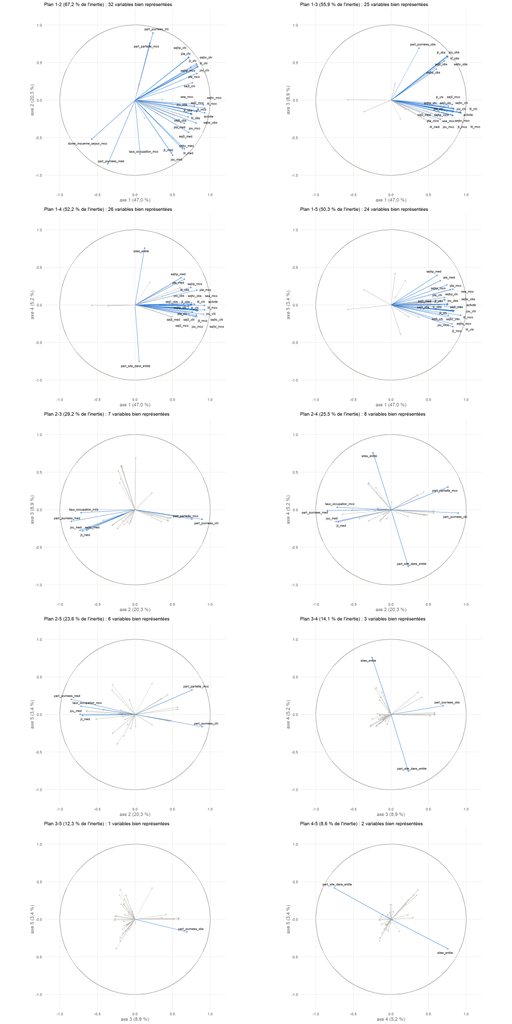

### 2.3 Contributions des variables aux axes

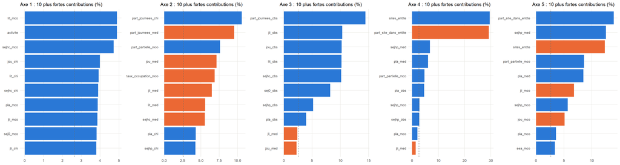

Bleu : corrélation positive avec l’axe ; orange : négative ; pointillé : contribution moyenne (2,6 %).

**Tableau complet : corrélations, cos² et contributions des 38 variables**

| variable | corr. axe 1 | corr. axe 2 | corr. axe 3 | corr. axe 4 | corr. axe 5 | cos² plan 1-2 | cos² 5 axes | ctr 1 (%) | ctr 2 (%) | ctr 3 (%) | ctr 4 (%) | ctr 5 (%) |
| --- | --- | --- | --- | --- | --- | --- | --- | --- | --- | --- | --- | --- |
| lit_obs | 0,76 | -0,19 | 0,59 | 0,03 | -0,00 | 0,61 | 0,96 | 3,23 | 0,46 | 10,21 | 0,04 | 0,00 |
| sejhc_obs | 0,76 | -0,19 | 0,59 | 0,00 | 0,01 | 0,62 | 0,96 | 3,25 | 0,46 | 10,14 | 0,00 | 0,01 |
| jou_obs | 0,76 | -0,18 | 0,59 | 0,01 | 0,01 | 0,61 | 0,96 | 3,23 | 0,44 | 10,22 | 0,00 | 0,01 |
| jli_obs | 0,75 | -0,18 | 0,59 | -0,00 | 0,01 | 0,60 | 0,95 | 3,16 | 0,43 | 10,33 | 0,00 | 0,01 |
| sejhc_chi | 0,83 | 0,47 | -0,11 | -0,08 | -0,08 | 0,92 | 0,94 | 3,90 | 2,88 | 0,38 | 0,30 | 0,54 |
| lit_med | 0,66 | -0,66 | -0,26 | -0,06 | 0,05 | 0,87 | 0,94 | 2,47 | 5,58 | 1,98 | 0,18 | 0,21 |
| jli_chi | 0,82 | 0,49 | -0,11 | -0,07 | -0,08 | 0,92 | 0,94 | 3,80 | 3,09 | 0,35 | 0,24 | 0,49 |
| lit_mco | 0,93 | -0,11 | -0,17 | -0,07 | -0,14 | 0,88 | 0,94 | 4,89 | 0,15 | 0,90 | 0,22 | 1,49 |
| lit_chi | 0,84 | 0,45 | -0,15 | -0,07 | -0,09 | 0,90 | 0,94 | 3,92 | 2,64 | 0,66 | 0,21 | 0,59 |
| jou_chi | 0,84 | 0,45 | -0,12 | -0,08 | -0,08 | 0,91 | 0,94 | 3,99 | 2,58 | 0,41 | 0,28 | 0,45 |
| part_journees_med | -0,37 | -0,86 | -0,16 | -0,01 | 0,20 | 0,87 | 0,93 | 0,75 | 9,52 | 0,73 | 0,01 | 3,29 |
| pla_mco | 0,83 | 0,36 | -0,16 | 0,20 | 0,21 | 0,82 | 0,93 | 3,87 | 1,68 | 0,76 | 2,00 | 3,55 |
| sejhc_med | 0,64 | -0,65 | -0,28 | -0,14 | 0,04 | 0,83 | 0,93 | 2,27 | 5,53 | 2,25 | 1,03 | 0,12 |
| activite | 0,93 | -0,17 | -0,16 | -0,01 | -0,03 | 0,90 | 0,93 | 4,89 | 0,37 | 0,77 | 0,00 | 0,06 |
| sejhc_mco | 0,92 | -0,06 | -0,17 | -0,13 | -0,19 | 0,85 | 0,93 | 4,72 | 0,05 | 0,82 | 0,80 | 2,95 |
| part_journees_chi | 0,24 | 0,90 | -0,13 | -0,04 | -0,16 | 0,87 | 0,92 | 0,32 | 10,57 | 0,49 | 0,10 | 2,08 |
| sejhp_mco | 0,75 | 0,44 | -0,15 | 0,24 | 0,27 | 0,76 | 0,91 | 3,17 | 2,55 | 0,64 | 2,81 | 5,66 |
| jou_med | 0,51 | -0,74 | -0,28 | -0,16 | 0,00 | 0,80 | 0,91 | 1,43 | 7,13 | 2,27 | 1,26 | 0,00 |
| jou_mco | 0,82 | -0,31 | -0,21 | -0,15 | -0,26 | 0,77 | 0,90 | 3,77 | 1,22 | 1,24 | 1,19 | 5,10 |
| sites_entite | 0,13 | -0,24 | -0,26 | 0,77 | -0,40 | 0,08 | 0,89 | 0,09 | 0,77 | 1,94 | 29,56 | 12,33 |
| part_site_dans_entite | 0,06 | 0,23 | 0,23 | -0,76 | 0,42 | 0,06 | 0,87 | 0,02 | 0,69 | 1,58 | 29,25 | 13,91 |
| pla_chi | 0,72 | 0,58 | -0,10 | -0,05 | 0,07 | 0,85 | 0,87 | 2,92 | 4,30 | 0,27 | 0,11 | 0,39 |
| sejhp_chi | 0,72 | 0,57 | -0,09 | -0,02 | 0,10 | 0,85 | 0,87 | 2,92 | 4,26 | 0,25 | 0,02 | 0,79 |
| jli_mco | 0,83 | -0,15 | -0,20 | -0,16 | -0,29 | 0,71 | 0,87 | 3,85 | 0,31 | 1,23 | 1,29 | 6,79 |
| jli_med | 0,49 | -0,71 | -0,28 | -0,16 | -0,01 | 0,74 | 0,85 | 1,34 | 6,51 | 2,39 | 1,34 | 0,01 |
| part_partielle_mco | 0,20 | 0,77 | -0,13 | 0,31 | 0,33 | 0,63 | 0,84 | 0,22 | 7,61 | 0,46 | 4,72 | 8,58 |
| sej0_obs | 0,72 | -0,23 | 0,53 | -0,02 | 0,01 | 0,56 | 0,84 | 2,87 | 0,67 | 8,21 | 0,01 | 0,00 |
| sejhp_med | 0,62 | -0,31 | -0,20 | 0,37 | 0,40 | 0,48 | 0,81 | 2,16 | 1,22 | 1,20 | 6,76 | 12,53 |
| pla_med | 0,67 | -0,31 | -0,21 | 0,35 | 0,33 | 0,54 | 0,81 | 2,48 | 1,26 | 1,31 | 6,05 | 8,48 |
| sej0_med | 0,72 | -0,43 | -0,14 | -0,12 | 0,06 | 0,71 | 0,75 | 2,92 | 2,44 | 0,61 | 0,73 | 0,32 |
| sej0_mco | 0,83 | -0,14 | -0,06 | -0,14 | -0,07 | 0,70 | 0,73 | 3,82 | 0,27 | 0,10 | 0,94 | 0,41 |
| sea_mco | 0,80 | -0,08 | -0,19 | 0,01 | 0,21 | 0,64 | 0,72 | 3,58 | 0,08 | 1,10 | 0,01 | 3,37 |
| sej0_chi | 0,77 | 0,24 | -0,08 | -0,10 | -0,14 | 0,65 | 0,69 | 3,33 | 0,72 | 0,19 | 0,46 | 1,55 |
| part_journees_obs | 0,38 | 0,01 | 0,70 | 0,12 | -0,17 | 0,14 | 0,68 | 0,80 | 0,00 | 14,44 | 0,70 | 2,27 |
| sejhp_obs | 0,61 | -0,20 | 0,42 | 0,23 | 0,06 | 0,41 | 0,65 | 2,09 | 0,50 | 5,20 | 2,74 | 0,29 |
| duree_moyenne_sejour_mco | -0,59 | -0,53 | 0,01 | -0,01 | -0,06 | 0,62 | 0,62 | 1,92 | 3,62 | 0,00 | 0,00 | 0,31 |
| pla_obs | 0,53 | -0,21 | 0,37 | 0,30 | 0,02 | 0,33 | 0,55 | 1,60 | 0,57 | 3,93 | 4,58 | 0,04 |
| taux_occupation_mco | 0,07 | -0,73 | -0,04 | 0,03 | 0,11 | 0,53 | 0,55 | 0,03 | 6,89 | 0,05 | 0,05 | 1,00 |

**Axe 1 (47,0 %) : la taille.** Toutes les quantités y sont corrélées positivement (activité 0,93, lits MCO 0,93, séjours de complète 0,92, journées de chirurgie 0,84). Les contributions sont étalées (au plus 4,9 %) : c’est l’**effet taille** classique d’une ACP sur des quantités, où tout grandit ensemble. Seuls deux ratios s’y opposent, faiblement : la durée moyenne de séjour (-0,59) et la part des journées de médecine (-0,37).

**Axe 2 (20,3 %) : la nature de l’activité, à taille donnée.** Côté positif, la part des journées de chirurgie (0,90, contribution 10,6 %), la part de la partielle (0,77, 7,6 %) et les quantités de chirurgie. Côté négatif, la part des journées de médecine (-0,86, 9,5 %), les journées de médecine (-0,74), le taux d’occupation (-0,73) et la durée de séjour (-0,53). L’axe oppose **la médecine en hospitalisation complète, longue et à forte occupation** à **la chirurgie et à l’ambulatoire**.

**Axe 3 (8,9 %) : l’obstétrique.** La part des journées d’obstétrique (0,70, contribution 14,4 %) et toutes les quantités d’obstétrique (lits 0,59, journées 0,59).

**Axe 4 (5,2 %) : la place du site dans son entité.** Le nombre de sites de l’entité (0,77) contre la part du site dans l’activité de l’entité (-0,76) : un petit site d’une grande entité multi-sites.

**Axe 5 (3,4 %) : l’activité médicale ambulatoire d’un site autonome.** Les venues et places de médecine (0,40 et 0,33), la part de la partielle (0,33), la part du site dans son entité (0,42) contre le nombre de sites (-0,40). C’est l’axe le plus fragile (bâton brisé).

### 2.4 Les faisceaux de variables

Un **faisceau** est un groupe de variables dont les flèches pointent dans la même direction : elles sont fortement corrélées entre elles et portent la même information. Deux faisceaux à angle droit sont décorrélés. Pour les repérer sans se fier à l’œil, on regroupe les variables selon leur corrélation sur les 5 axes retenus (classification ascendante hiérarchique, distance 1 − corrélation entre les vecteurs reconstruits sur 5 axes, saut de Ward).

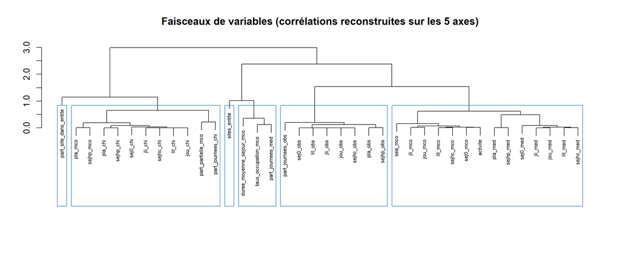

| faisceau | variables | n | axe dominant | corr. moyenne interne |
| --- | --- | --- | --- | --- |
| 1,00 | lit_med, lit_mco, jli_med, jli_mco, jou_med, jou_mco, sejhc_med, sejhc_mco, sej0_med, sej0_mco, pla_med, sejhp_med, sea_mco, activite | 14,00 | 1,00 | 0,81 |
| 2,00 | lit_chi, jli_chi, jou_chi, sejhc_chi, sej0_chi, pla_chi, pla_mco, sejhp_chi, sejhp_mco, part_partielle_mco, part_journees_chi | 11,00 | 1,00 | 0,84 |
| 3,00 | lit_obs, jli_obs, jou_obs, sejhc_obs, sej0_obs, pla_obs, sejhp_obs, part_journees_obs | 8,00 | 1,00 | 0,94 |
| 4,00 | sites_entite | 1,00 | 4,00 | 1,00 |
| 5,00 | taux_occupation_mco, duree_moyenne_sejour_mco, part_journees_med | 3,00 | 2,00 | 0,77 |
| 6,00 | part_site_dans_entite | 1,00 | 4,00 | 1,00 |

**Trois faisceaux de quantités, tous tournés vers la droite de l’axe 1 (la taille)** : la médecine et les totaux, avec l’activité (14 variables, corrélation interne moyenne 0,81) ; la chirurgie et l’ambulatoire (11 variables, 0,84) ; l’obstétrique (8 variables, 0,94). Ils grandissent ensemble avec la taille ; ce qui les distingue, c’est l’axe 2 (médecine contre chirurgie et ambulatoire) et l’axe 3 (obstétrique).

**Un faisceau de la médecine longue** : le taux d’occupation, la durée moyenne de séjour et la part des journées de médecine (3 variables, 0,77). Son axe dominant est l’axe 2 : c’est le pôle opposé au faisceau de la chirurgie et de l’ambulatoire.

**La place dans l’entité** : le nombre de sites de l’entité et la part du site dans son entité restent chacun seuls, parce qu’ils sont **opposés** (corrélation -0,98 sur les 5 axes) : la distance 1 − corrélation sépare deux variables de sens contraire, qui portent la même information. Ils sont presque à angle droit du plan 1-2 (cos² au plus 0,08) : ils portent une information que la taille et la nature de l’activité ne contiennent pas (axe 4).

## 3. Les individus (espace direct)

La **contribution** d’un passage à un axe est sa coordonnée au carré divisée par n × valeur propre (moyenne : 100 / 11 587 = 0,009 %). Son **cos²** sur un axe est sa coordonnée au carré divisée par sa distance au centre au carré.

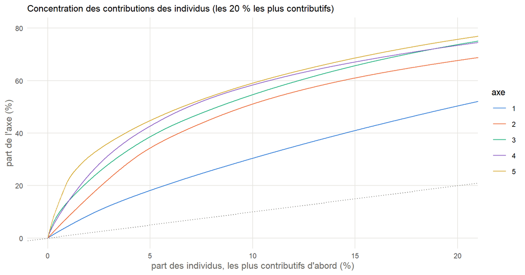

| axe | contribution max (%) | 10 premiers (%) | 1 % des individus (%) | nb > 10 × moyenne |
| --- | --- | --- | --- | --- |
| 1,000 | 0,046 | 0,451 | 4,534 | 0,000 |
| 2,000 | 0,077 | 0,756 | 8,060 | 0,000 |
| 3,000 | 0,208 | 2,047 | 13,948 | 90,000 |
| 4,000 | 0,209 | 1,925 | 13,842 | 186,000 |
| 5,000 | 0,266 | 2,617 | 21,978 | 140,000 |

**Aucun passage ne domine un axe** : la plus forte contribution est de 0,27 %.

**Les axes 1 et 2 sont construits par toute la population** : les 10 premiers passages en font 0,45 % et 0,76 %, le 1 % le plus contributif 4,5 % et 8,1 %.

**Les axes 3 à 5 sont construits par des groupes spécialisés** : le 1 % le plus contributif en fait 14 %, 14 %, 22 %. Le tableau ci-dessous montre lesquels : des maternités (axe 3), des petits sites de CHU multi-sites (axe 4), des centres d’endoscopie autonomes (axe 5).

**Attention aux années répétées** : un même établissement contribue à chaque année où il est présent ; le tableau ne garde que l’année la plus contributive de chaque établissement.

| axe | FINESS | établissement (année) | années présentes | classe | coordonnée | ctr (%) | cos² |
| --- | --- | --- | --- | --- | --- | --- | --- |
| 1,000 | 330781360 | GROUPE HOSPITALIER PELLEGRIN - CHU (2021) | 8,000 | stable | 9,784 | 0,046 | 0,806 |
| 1,000 | 440000271 | CHU DE NANTES SITE HOTEL DIEU HME (2022) | 8,000 | stable | 9,400 | 0,043 | 0,836 |
| 1,000 | 750100125 | HU PITIE SALPETRIERE APHP (2017) | 8,000 | stable | 9,375 | 0,042 | 0,696 |
| 1,000 | 750100166 | GPE HOSP COCHIN-SAINT VINCENT DE PAUL (2014) | 8,000 | stable | 9,250 | 0,041 | 0,654 |
| 1,000 | 760000158 | HOPITAL CHARLES NICOLLE CHU ROUEN (2013) | 8,000 | stable | 9,219 | 0,041 | 0,869 |
| 2,000 | 330780487 | CLINIQUE OPHTALMOLOGIQUE THIERS (2022) | 8,000 | stable | 8,307 | 0,077 | 0,773 |
| 2,000 | 130044753 | CLINIQUE MONTICELLI VELODROME (2021) | 4,000 | stable | 8,240 | 0,076 | 0,844 |
| 2,000 | 570000364 | CLINIQUE NOTRE DAME DE THIONVILLE (2021) | 8,000 | stable | 8,236 | 0,076 | 0,854 |
| 2,000 | 590780060 | INSTITUT OPHTALMIQUE (2021) | 8,000 | stable | 8,169 | 0,075 | 0,713 |
| 2,000 | 330060658 | GCS CLINIQUE CHIRURGICALE LIBOURNAIS (2022) | 2,000 | stable | 8,114 | 0,074 | 0,854 |
| 3,000 | 750150013 | HOPITAL PIERRE ROUQUES -LES BLUETS (2015) | 8,000 | stable | 9,050 | 0,208 | 0,610 |
| 3,000 | 760780197 | CLINIQUE LES AUBEPINES ST-AUBIN-S/SCIE (2018) | 6,000 | sortie | 8,983 | 0,205 | 0,608 |
| 3,000 | 930150032 | MATERNITE DES LILAS (2018) | 8,000 | stable | 8,967 | 0,205 | 0,617 |
| 3,000 | 970112835 | POLYCLINIQUE DE GUADELOUPE (SITE CHU) (2018) | 1,000 | stable | 8,567 | 0,187 | 0,538 |
| 3,000 | 510024300 | GCS -MATERNITÉ D’ÉPERNAY- (2013) | 4,000 | stable | 8,291 | 0,175 | 0,530 |
| 4,000 | 310783063 | HOPITAL LA GRAVE CHU TLSE (2021) | 5,000 | stable | 6,939 | 0,209 | 0,268 |
| 4,000 | 440003291 | CHU DE NANTES SITE SAINT JACQUES (2021) | 4,000 | stable | 6,393 | 0,178 | 0,232 |
| 4,000 | 930100045 | HU PARIS SITE JEAN VERDIER APHP (2021) | 8,000 | stable | 6,307 | 0,173 | 0,439 |
| 4,000 | 590047718 | HOPITAL DE JOUR ALCOOLOGIE (2013) | 1,000 | stable | 5,884 | 0,150 | 0,198 |
| 4,000 | 920100062 | HU PARIS OUEST SITE CELTON APHP (2018) | 8,000 | stable | 5,755 | 0,144 | 0,548 |
| 5,000 | 380013037 | CENTRE D’ENDOSCOPIE NORD ISERE (2021) | 8,000 | stable | 6,266 | 0,266 | 0,236 |
| 5,000 | 670013325 | CTRE AUTONOME D’ENDOSC DIGESTIVE AMBUL (2022) | 8,000 | stable | 6,266 | 0,266 | 0,235 |
| 5,000 | 340000025 | INSTITUT ST PIERRE PALAVAS LES FLOTS (2022) | 2,000 | stable | 6,114 | 0,253 | 0,219 |
| 5,000 | 540014073 | CHS CENTRE PSYCHOTHERAPIQUE DE NANCY (2022) | 2,000 | stable | 6,109 | 0,253 | 0,219 |
| 5,000 | 690029186 | ENDO LYON SUD OUEST (2022) | 8,000 | stable | 6,035 | 0,246 | 0,214 |

### 3.1 Qualité de représentation des individus

Sur le plan 1-2, le cos² des passages a pour médiane 0,70 (premier décile 0,26, dernier décile 0,91) : **29 % des passages ont un cos² inférieur à 0,5** et ne doivent pas être interprétés sur ce plan. Les décrochages et les sorties sont mieux représentés que les stables (cos² médian 0,78 contre 0,69).

La distance au centre au carré vaut 38,0 en moyenne (le nombre de variables), 32,3 en médiane, et jusqu’à 180 : une minorité de passages très excentrés, les plus grands et les plus spécialisés.

### 3.2 ACP de contrôle

Les passages dont la contribution dépasse 10 fois la moyenne sur l’un des axes 1 à 3 deviennent supplémentaires, et l’ACP est refaite sans eux.

| axe | valeur propre (ACP complète) | valeur propre (contrôle) | \|corrélation des vecteurs propres\| |
| --- | --- | --- | --- |
| 1,000 | 17,848 | 18,074 | 0,999 |
| 2,000 | 7,698 | 7,773 | 1,000 |
| 3,000 | 3,390 | 3,190 | 0,997 |
| 4,000 | 1,985 | 1,974 | 0,999 |
| 5,000 | 1,275 | 1,261 | 0,998 |

90 passages retirés. **Les axes tiennent** : les valeurs propres changent à peine et les vecteurs propres restent corrélés à au moins 0,997 avec ceux de l’ACP complète. Les axes ne sont pas créés par quelques établissements atypiques.

## 4. Le lien entre les deux espaces, et les classes

### 4.1 Les individus : les 10 plans des 5 axes retenus

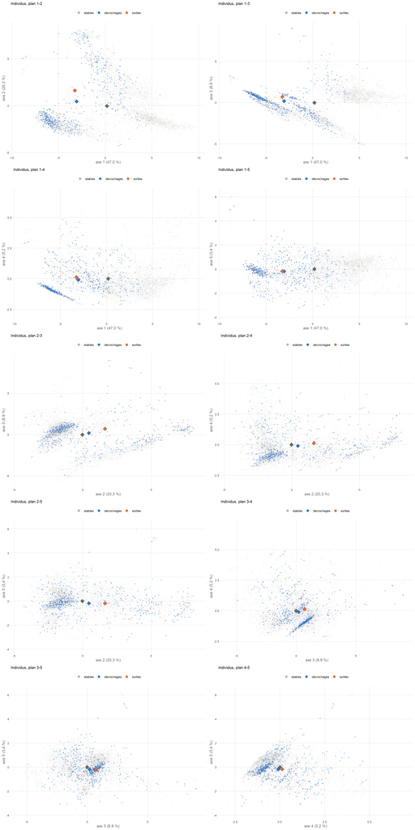

**Les traînées droites des plans 1-3 et 1-4.** Beaucoup de décrochages s’alignent sur des droites. Ce sont des **établissements de médecine seule** : ni chirurgie, ni obstétrique, ni place de partielle (2 471 passages, dont 10,5 % de y = 1, contre 5,2 % sur tout l’entraînement ; ils regroupent 44 % des décrochages). Leurs journées et leurs venues de chirurgie et d’obstétrique valent 0 : ces colonnes sont identiques d’un établissement à l’autre, et seules leurs quantités de médecine varient, surtout avec la taille. Leurs points ne bougent donc presque que dans une seule direction : sur ce groupe, la corrélation entre les axes 1 et 3 vaut -0,88 (et -0,27 entre les axes 1 et 4), contre 0,10 pour les autres passages. Une traînée n’est donc pas un phénomène caché : c’est la trace géométrique de beaucoup de zéros identiques.

Pour les modèles, ce groupe compte : il réunit une part importante des décrochages, et c’est le premier amas du plan 1-2 (petits établissements de médecine). Un modèle fondé sur des distances (k plus proches voisins) verra ces passages très proches les uns des autres, quelle que soit leur classe.

### 4.2 Les modalités supplémentaires

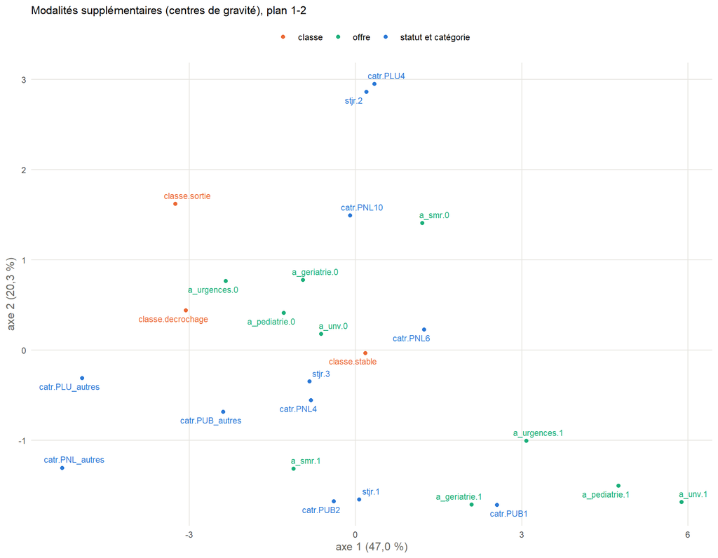

| modalité | effectif | coord. 1 | coord. 2 | coord. 3 | coord. 4 | coord. 5 | v-test 1 | v-test 2 | v-test 3 | v-test 4 | v-test 5 |
| --- | --- | --- | --- | --- | --- | --- | --- | --- | --- | --- | --- |
| classe.decrochage | 542,00 | -3,07 | 0,44 | 0,19 | -0,09 | -0,18 | -17,32 | 3,80 | 2,45 | -1,57 | -3,81 |
| classe.sortie | 65,00 | -3,26 | 1,62 | 0,70 | 0,13 | -0,17 | -6,24 | 4,72 | 3,07 | 0,73 | -1,25 |
| classe.stable | 10 980,00 | 0,17 | -0,03 | -0,01 | 0,00 | 0,01 | 18,51 | -5,18 | -3,35 | 1,24 | 4,03 |
| stjr.1 | 6 367,00 | 0,06 | -1,65 | 0,14 | 0,12 | -0,03 | 1,82 | -70,88 | 8,85 | 9,78 | -3,66 |
| stjr.2 | 3 847,00 | 0,19 | 2,86 | -0,05 | -0,22 | 0,02 | 3,43 | 78,28 | -2,25 | -12,11 | 1,59 |
| stjr.3 | 1 373,00 | -0,84 | -0,35 | -0,48 | 0,09 | 0,10 | -7,80 | -4,95 | -10,33 | 2,59 | 3,33 |
| a_pediatrie.0 | 9 095,00 | -1,30 | 0,41 | -0,15 | -0,02 | -0,06 | -63,31 | 30,51 | -17,10 | -3,63 | -10,83 |
| a_pediatrie.1 | 2 492,00 | 4,75 | -1,50 | 0,56 | 0,09 | 0,22 | 63,31 | -30,51 | 17,10 | 3,63 | 10,83 |
| a_geriatrie.0 | 7 969,00 | -0,95 | 0,78 | 0,00 | -0,09 | -0,07 | -35,96 | 44,77 | 0,17 | -10,27 | -9,76 |
| a_geriatrie.1 | 3 618,00 | 2,09 | -1,71 | -0,00 | 0,20 | 0,15 | 35,96 | -44,77 | -0,17 | 10,27 | 9,76 |
| a_unv.0 | 10 476,00 | -0,62 | 0,18 | 0,02 | -0,02 | -0,03 | -48,81 | 21,28 | 3,78 | -5,14 | -8,27 |
| a_unv.1 | 1 111,00 | 5,88 | -1,68 | -0,20 | 0,21 | 0,27 | 48,81 | -21,28 | -3,78 | 5,14 | 8,27 |
| a_urgences.0 | 6 582,00 | -2,34 | 0,76 | 0,02 | 0,14 | -0,09 | -68,51 | 34,02 | 1,10 | 12,43 | -9,42 |
| a_urgences.1 | 5 005,00 | 3,08 | -1,01 | -0,02 | -0,19 | 0,11 | 68,51 | -34,02 | -1,10 | -12,43 | 9,42 |
| a_smr.0 | 5 595,00 | 1,20 | 1,41 | -0,00 | 0,07 | 0,00 | 29,53 | 52,83 | -0,17 | 4,81 | 0,07 |
| a_smr.1 | 5 992,00 | -1,12 | -1,32 | 0,00 | -0,06 | -0,00 | -29,53 | -52,83 | 0,17 | -4,81 | -0,07 |
| inc_occupation_superieure_a_1_5.0 | 11 554,00 | 0,01 | 0,00 | -0,00 | 0,00 | -0,00 | 5,93 | 1,93 | -0,58 | 0,01 | -1,79 |
| inc_occupation_superieure_a_1_5.1 | 33,00 | -4,35 | -0,93 | 0,18 | -0,00 | 0,35 | -5,93 | -1,93 | 0,58 | -0,01 | 1,79 |

**Catégories d’établissement et régions en supplémentaire**

| modalité | effectif | coord. 1 | coord. 2 | coord. 3 |
| --- | --- | --- | --- | --- |
| catr.PLU_autres | 107,00 | -4,94 | -0,31 | 0,39 |
| catr.PLU4 | 3 740,00 | 0,34 | 2,95 | -0,07 |
| catr.PNL_autres | 100,00 | -5,30 | -1,31 | 0,23 |
| catr.PNL10 | 112,00 | -0,10 | 1,49 | -0,27 |
| catr.PNL4 | 997,00 | -0,81 | -0,55 | -0,23 |
| catr.PNL6 | 164,00 | 1,24 | 0,23 | -2,60 |
| catr.PUB_autres | 188,00 | -2,39 | -0,68 | -0,99 |
| catr.PUB1 | 1 126,00 | 2,55 | -1,72 | -1,23 |
| catr.PUB2 | 5 053,00 | -0,40 | -1,68 | 0,48 |
| region.11 | 1 734,00 | 0,76 | 0,34 | 0,04 |
| region.24 | 395,00 | 0,32 | -0,36 | 0,03 |
| region.27 | 601,00 | -0,98 | -0,53 | -0,09 |
| region.28 | 603,00 | -0,06 | -0,02 | -0,01 |
| region.32 | 989,00 | 0,49 | 0,14 | -0,02 |
| region.44 | 1 097,00 | -0,17 | -0,29 | -0,15 |
| region.52 | 554,00 | -0,27 | -0,03 | 0,08 |
| region.53 | 566,00 | -0,27 | -0,57 | -0,17 |
| region.75 | 1 105,00 | -0,03 | 0,17 | -0,08 |
| region.76 | 1 095,00 | -0,26 | -0,16 | -0,01 |
| region.84 | 1 439,00 | -0,46 | -0,22 | 0,08 |
| region.93 | 996,00 | 0,24 | 0,75 | -0,12 |
| region.94 | 103,00 | -1,63 | 0,42 | 0,28 |
| region.outre_mer | 310,00 | 0,28 | -0,25 | 0,95 |

**Les classes** : le centre de gravité des décrochages est à (-3,07 ; 0,44 ; 0,19) sur les axes 1 à 3, celui des sorties à (-3,26 ; 1,62 ; 0,70), celui des stables près de l’origine. Les valeurs-tests sont -17,3 et -6,2 sur l’axe 1, puis 3,8 et 4,7 sur l’axe 2. La corrélation de y avec les axes vaut axe 1 : -0,172 ; axe 2 : 0,048 ; axe 3 : 0,031 ; axe 4 : -0,012 ; axe 5 : -0,037.

**Lecture** : les décrochages et les sorties sont d’abord des **petits établissements** (axe 1). Les sorties penchent en plus vers la **chirurgie et l’ambulatoire** (axe 2) et un peu vers l’obstétrique (axe 3). Au-delà de la taille, le lien de y avec les axes est faible.

Avec plus de 11 000 passages, une valeur-test dépasse 2 presque à coup sûr. C’est la **taille des coordonnées** qui compte : seul l’écart sur l’axe 1 est grand (environ 0,7 écart-type de l’axe pour les décrochages).

**Statut et catégorie** : l’axe 2 sépare aussi le **privé lucratif** (2,86, catégorie PLU4 2,95) du **public** (-1,65, centres hospitaliers PUB2 -1,68). Les CHU et CHR (PUB1) sont à droite sur l’axe 1 (2,55). Les petites catégories regroupées (PLU_autres, PNL_autres) sont très à gauche (-4,94 et -5,30).

**Offre** : avoir des urgences (3,08) ou de la pédiatrie (4,75) place un passage à droite sur l’axe 1, du côté des gros établissements ; avoir du SMR le place à gauche et vers la médecine (-1,12 ; -1,32).

## 5. Ce que j’en retiens, avec prudence

1. La variance des établissements est d’abord une affaire de **taille** (47 %), puis de **nature d’activité** (20 %), d’**obstétrique** (9 %) et de **place dans l’entité** (5 %).
2. Les y = 1 se distinguent surtout sur l’axe de la taille, ce qu’exploite déjà la règle naïve. Les autres axes ne les séparent que faiblement. **Un modèle devra tirer son gain de combinaisons que l’ACP, linéaire et faite pour la variance, ne montre pas** : interactions, effets de seuil, indicateurs.
3. Les classes se recouvrent largement dans tous les plans : la séparation sera difficile, et la PR-AUC à attendre reste modeste.
4. Pour les k plus proches voisins, travailler sur 5 composantes plutôt que sur 38 variables a du sens (fléau de la dimension) : c’est la variante « ACP puis k voisins », réapprise dans chaque pli, en Python, avec la logistique pour comparaison.

**Limites** : un individu par année (les grands établissements comptent plusieurs fois) ; cases vides remplacées par la médiane et deux ratios plafonnés, pour l’ACP seulement ; ACP linéaire, qui décrit la variance et non la séparation des classes.